# Public Transportation Ridership Analysis: Chicago Case Study

Marisol Muñiz

## Introduction

### Objectives

- **Gain an understanding of public transportation ridership trends**
- **Provide analysis to guide performance improvement strategies**

### Study Area

- Chicago, Illinois ([Chicago Open Data Portal](https://data.cityofchicago.org/))
- Rail and bus ridership totals by day, month, and year
  - Rail: ridership by stations
  - Bus: ridership by routes

## Software Needed

### Install R libraries

```r
if (!require(readr)) install.packages("readr")
library(readr)
if (!require(dplyr)) install.packages("dplyr")
library(dplyr)
if (!require(DT)) install.packages("DT")
library(DT)
if (!require(ggrepel)) install.packages("ggrepel")
library(ggrepel)
if (!require(fBasics)) install.packages("fBasics")
library(fBasics)
```

## Data Preprocessing

### Read the data

```r
library(readr)
annual.total <- read.csv(file="C:/Users/Admin/Desktop/533 GEOG/zProject/Data/1_Boarding_Totals_Annual.csv", header=TRUE, sep=",")
daily.rail <- read.csv(file="C:/Users/Admin/Desktop/533 GEOG/zProject/Data/5_Rail_Stations_Daily.csv", header=TRUE, sep=",")
daily.bus <- read.csv(file="C:/Users/Admin/Desktop/533 GEOG/zProject/Data/6_Bus_Routes_Daily.csv", header=TRUE, sep=",")
```

## Total Annual Ridership

### Display data

Display the data using DT and datatable().

```r
library(DT)

datatable(annual.total, options = list(pageLength = 5,scrollX = '400px'))
```

|  | year | bus | paratransit | rail | total |
| --- | --- | --- | --- | --- | --- |
| 1 | 1988 | 430089500 | 435400 | 174436000 | 604960900 |
| 2 | 1989 | 420572700 | 924800 | 168658800 | 590156300 |
| 3 | 1990 | 421183734 | 930802 | 165732575 | 587847111 |
| 4 | 1991 | 392088602 | 949460 | 147608116 | 540646178 |
| 5 | 1992 | 370335119 | 1011669 | 137372830 | 508719618 |
| 6 | 1993 | 326655953 | 1167904 | 135369734 | 463193591 |
| 7 | 1994 | 331520700 | 1209900 | 143579100 | 476309700 |
| 8 | 1995 | 306075585 | 1270274 | 135461619 | 442807478 |
| 9 | 1996 | 302115116 | 1244209 | 142040486 | 445399811 |
| 10 | 1997 | 287628293 | 1235085 | 151010374 | 439873752 |

[output cut: 20 more lines]

```r
sprintf("Number of Rows in Dataframe: %s", format(nrow(annual.total),big.mark = ","))
```

```
[1] "Number of Rows in Dataframe: 30"
```

### Visualize Data and Trends

Visualize annual trends in total public transportation ridership.

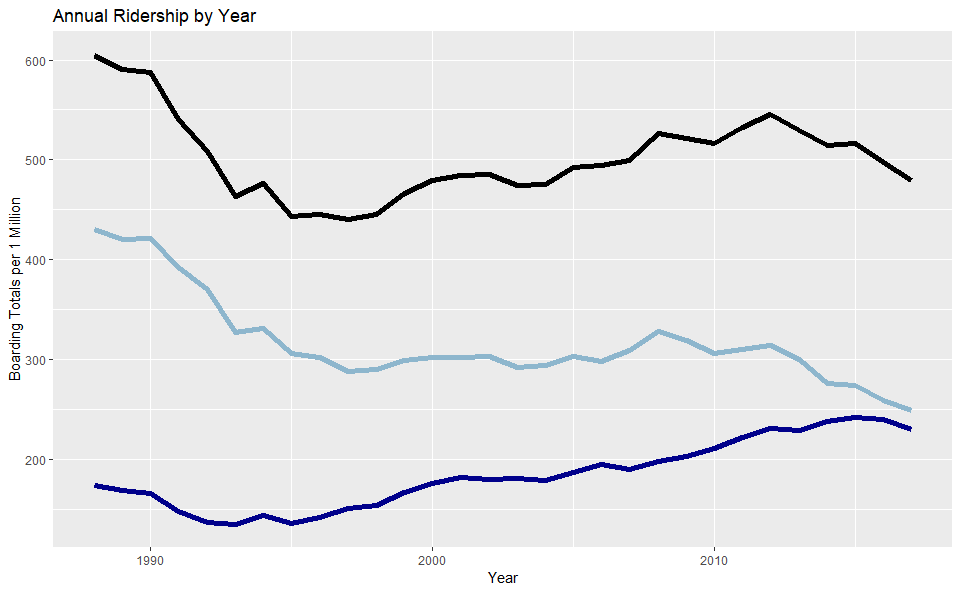

```r
annual.total["Total.Per1mil"] <- annual.total$total/1000000
annual.total["Rail.Per1mil"] <- annual.total$rail/1000000
annual.total["Bus.Per1mil"] <- annual.total$bus/1000000

p.1 <- ggplot(annual.total) +
  geom_line(aes(x = year, y = Total.Per1mil), size = 2, color = "black") +
  geom_line(aes(x = year, y = Rail.Per1mil), size = 2, color = "blue4") +
  geom_line(aes(x = year, y = Bus.Per1mil), size = 2, color = "lightskyblue3") +
  ggtitle('Annual Ridership by Year') +
  labs (x = "Year", y = "Boarding Totals per 1 Million")

print(p.1)
```

### Data Analysis

```r
#Summary Statistics
annual.stats <- data.frame("Type" = c("Total", "Rail", "Bus"), "Minimum Ridership" = c(min(annual.total$total), min(annual.total$rail), min(annual.total$bus)), "Maximum Ridership"= c(max(annual.total$total), max(annual.total$rail), max(annual.total$bus)), "Mean Ridership" = c(mean(annual.total$total), mean(annual.total$rail), mean(annual.total$bus)), "Standard of Dev" = c(sd(annual.total$total), sd(annual.total$rail), sd(annual.total$bus)))
print(annual.stats)
```

| Type | Minimum.Ridership | Maximum.Ridership | Mean.Ridership | Standard.of.Dev |
| --- | --- | --- | --- | --- |
| Total | 439873752 | 604960900 | 502552839 | 42652918 |
| Rail | 135369734 | 241676065 | 184491808 | 33884373 |
| Bus | 249231171 | 430089500 | 317273931 | 45414609 |

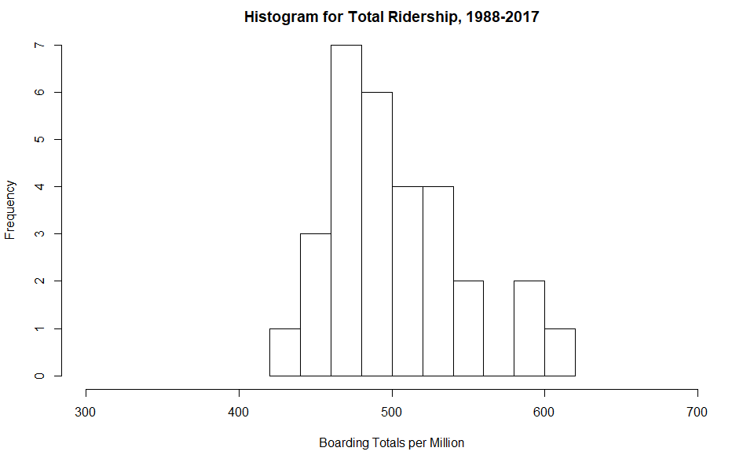

```r
#Data Distribution
hist(annual.total$Total.Per1mil, main = "Histogram for Total Ridership, 1988-2017", xlab = "Boarding Totals per Million", xlim = c(300, 700))
```

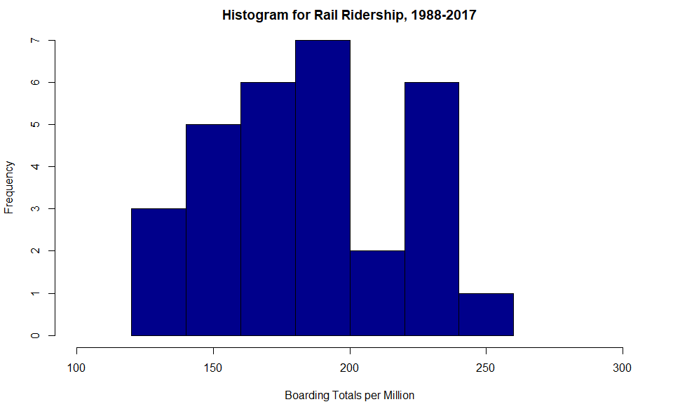

```r
hist(annual.total$Rail.Per1mil, main = "Histogram for Rail Ridership, 1988-2017", col = "blue4", xlab = "Boarding Totals per Million", xlim = c(100, 300))
```

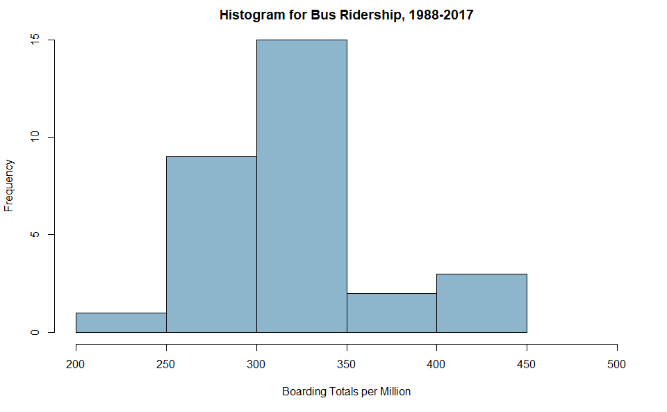

```r
hist(annual.total$Bus.Per1mil, main = "Histogram for Bus Ridership, 1988-2017", col = "lightskyblue3", xlab = "Boarding Totals per Million", xlim = c(200, 500))
```

#### Statistical Analysis

Determine whether or not the means for rail and bus ridership are statistically different.

*Null hypothesis*

$H_o:\mu1 = \mu2$

*Alternative hypothesis*

$H_{\alpha}:\mu \neq \mu2$

```r
ann.ttest <- t.test(annual.total$rail, annual.total$bus)
if(ann.ttest$p.value>0.05){
  print("We cannot reject the null hypothesis")
} else { print("We reject the null hypothesis")}
```

```
[1] "We reject the null hypothesis"
```

*Interpretation of Results:* Results of the two-sample t-test indicate that the two means, annual rail ridership and annual bus ridership, are not equal.

## Daily Ridership: Rail

### Display data

Display the data using DT and datatable().

```r
# display the first 100 rows
daily.rail.sub <- daily.rail[1:100,]
datatable(daily.rail.sub, options = list(pageLength = 5,scrollX = '400px'))
```

|  | station_id | stationname | date | daytype | rides |
| --- | --- | --- | --- | --- | --- |
| 1 | 40350 | UIC-Halsted | 01/01/2001 | U | 273 |
| 2 | 41130 | Halsted-Orange | 01/01/2001 | U | 306 |
| 3 | 40760 | Granville | 01/01/2001 | U | 1059 |
| 4 | 40070 | Jackson/Dearborn | 01/01/2001 | U | 649 |
| 5 | 40090 | Damen-Brown | 01/01/2001 | U | 411 |
| 6 | 40590 | Damen/Milwaukee | 01/01/2001 | U | 870 |
| 7 | 40720 | East 63rd-Cottage Grove | 01/01/2001 | U | 391 |
| 8 | 41260 | Austin-Lake | 01/01/2001 | U | 399 |
| 9 | 40230 | Cumberland | 01/01/2001 | U | 788 |
| 10 | 41120 | 35-Bronzeville-IIT | 01/01/2001 | U | 448 |

[output cut: 90 more lines]

```r
sprintf("Number of Rows in Dataframe: %s", format(nrow(daily.rail),big.mark = ","))
```

```
[1] "Number of Rows in Dataframe: 927,848"
```

### Data Analysis

#### Summary Statistics

```r
library(stats)
#Summary statistics
#Data distribution
```

#### Statistical Analysis

*Null hypothesis*

$H_o:\rho=0$

*Alternative hypothesis*

$H_{\alpha}:\rho \neq 0$

```r
#ANOVA analysis
```

## Daily Ridership: Bus

### Display data

Display the data using DT and datatable().

```r
# display the first 100 rows
daily.bus.sub <- daily.bus[1:100,]
datatable(daily.bus.sub, options = list(pageLength = 5,scrollX = '400px'))
```

|  | route | date | daytype | rides |
| --- | --- | --- | --- | --- |
| 1 | 3 | 01/01/2001 | U | 7354 |
| 2 | 4 | 01/01/2001 | U | 9288 |
| 3 | 6 | 01/01/2001 | U | 6048 |
| 4 | 8 | 01/01/2001 | U | 6309 |
| 5 | 9 | 01/01/2001 | U | 11207 |
| 6 | 10 | 01/01/2001 | U | 385 |
| 7 | 11 | 01/01/2001 | U | 610 |
| 8 | 12 | 01/01/2001 | U | 3678 |
| 9 | 18 | 01/01/2001 | U | 375 |
| 10 | 20 | 01/01/2001 | U | 7096 |

[output cut: 90 more lines]

```r
sprintf("Number of Rows in Dataframe: %s", format(nrow(daily.bus),big.mark = ","))
```

```
[1] "Number of Rows in Dataframe: 796,599"
```

### Data Analysis

#### Summary Statistics

```r
#Summary statistics
#Data Distribution
```

#### Statistical Analysis

*Null hypothesis*

$H_o:\rho=0$

*Alternative hypothesis*

$H_{\alpha}:\rho \neq 0$

```r
#ANOVA analysis
```

## References

- Annual Data
  - [Rail and Bus: Annual Ridership Totals](https://data.cityofchicago.org/Transportation/CTA-Ridership-Annual-Boarding-Totals/w8km-9pzd)
- Monthly Data
  - [Rail: Monthly Ridership by Station](https://data.cityofchicago.org/Transportation/CTA-Ridership-L-Station-Entries-Monthly-Day-Type-A/t2rn-p8d7)
  - [Bus: Monthly Ridership by Routes](https://data.cityofchicago.org/Transportation/CTA-Ridership-Bus-Routes-Monthly-Day-Type-Averages/bynn-gwxy)
- Daily Data
  - [Rail and Bus: Daily Ridership Totals](https://data.cityofchicago.org/Transportation/CTA-Ridership-Daily-Boarding-Totals/6iiy-9s97)
  - [Rail: Daily Ridership by Station](https://data.cityofchicago.org/Transportation/CTA-Ridership-L-Station-Entries-Daily-Totals/5neh-572f)
  - [Bus: Daily Ridership by Route](https://data.cityofchicago.org/Transportation/CTA-Ridership-Bus-Routes-Daily-Totals-by-Route/jyb9-n7fm)